# Cosumnes River

Sadie Gill, Mark Tompkins

July 2020

## Future Data Improvements

None planned.

## Instream Spawning and Rearing Habitat

**Data Source:** [Calaveras, FISHBIO Environmental and Thomas R. Payne & Associates 2009](https://s3-us-west-2.amazonaws.com/cvpiahabitat-r-package/cvpia-sit-model-inputs/FishBio_Payne2009_CalaverasInstreamFlowStudy.pdf) and [Mokelumne, CDFW 1991](https://s3-us-west-2.amazonaws.com/cvpiahabitat-r-package/cvpia-sit-model-inputs/Lower+Mokelumne+RIver+Fisheries+Management+Plan%2C+CDFG+1991.pdf)

There were no watershed specific salmonid habitat data available for the Consumnes River. A regional weighted usable area (WUA) and flow relationship was derived for the Consumnes River by averaging the WUA values on the Calaveras River and the Mokelumne River. The geomorphic and hydrologic conditions in the Consumnes River (watershed area = 2124 sqkm; active channel width = 27.25 meters) are similar to those on the Calaveras River (watershed area = 1369 sqkm; active channel width = 10.2) and the Mokelumne River (watershed area = 3070 sqkm; active channel width = 10.4 m). The regional WUA relationships for the Consumnes River were multiplied by the length of the spawning and rearing extents mapped by the Science Integration Team (SIT).

### Spawning and Rearing Data

The instream spawning and rearing habitat data described above for Fall Run Chinook Salmon (FR) is combined for use in the Decision Support Model (DSM) in the following format. Units are in square feet per 1000 feet.

Header Descriptions: flow_cfs = flow in cubic feet per second, FR_spawn_wua = Fall Run Chinook Spawning WUA, FR_fry_wua = Fall Run Chinook Fry WUA, FR_juv_wua = Fall Run Chinook Juvenile WUA, watershed = section of stream modeled for CVPIA SDM

| flow_cfs | FR_spawn_wua | FR_fry_wua | FR_juv_wua | watershed |
| --- | --- | --- | --- | --- |
| 100 | 6978.472 | 14915.550 | 18469.62 | Cosumnes River |
| 200 | 7712.700 | 12673.954 | 16980.69 | Cosumnes River |
| 300 | 7224.635 | 10806.262 | 16156.68 | Cosumnes River |
| 400 | 7121.988 | 9442.119 | 14428.71 | Cosumnes River |
| 500 | 7539.158 | 8159.457 | 12733.36 | Cosumnes River |

*… with 5 more rows*

### Spawning WUA

The following plot shows the spawning WUA in square feet per thousand feet for Fall Run Chinook Salmon. These area per length rates are multiplied by the total spawning reach length mapped by the SIT to estimate available habitat.

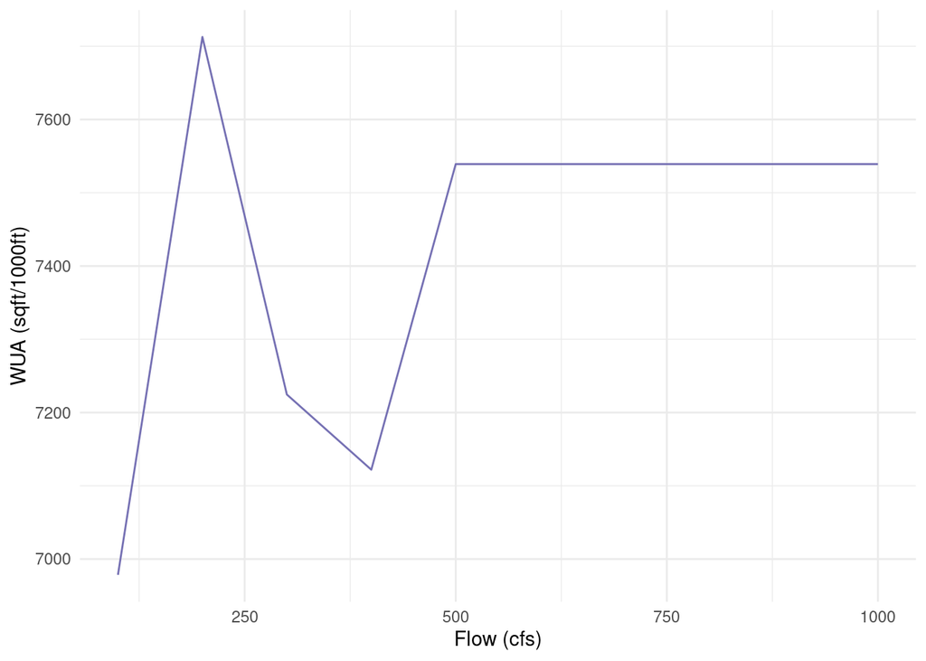

### Rearing WUA

The following plot shows the rearing WUA in square feet per thousand feet for Fall Run Chinook Salmon fry and juvenile. These rates are multiplied by the total rearing reach length mapped by the SIT to estimate available habitat.

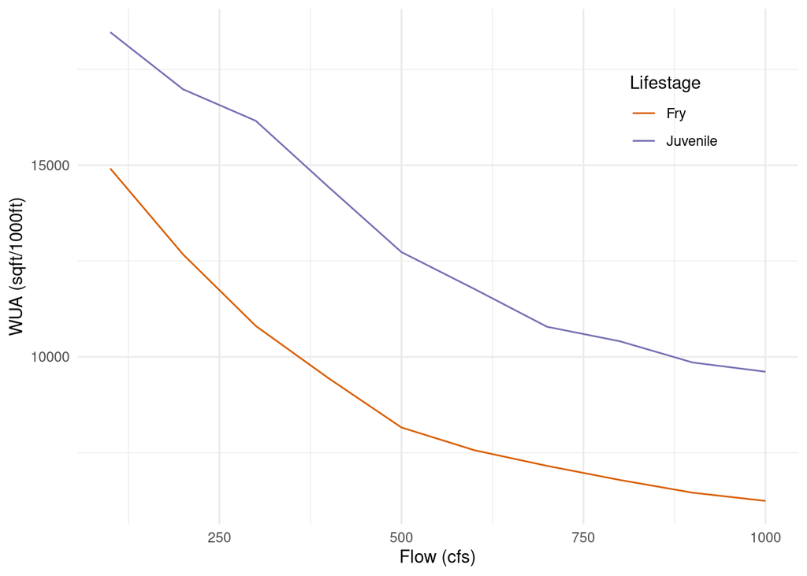

## Floodplain Rearing Habitat

**Data Source:** [CVPIA Annual Progress Report Fiscal Year 2019](https://cvpiahabitat-r-package.s3.us-west-2.amazonaws.com/cvpia-sit-model-inputs/CVPIA+Annual+Progress+Report+Fiscal+Year+2019.pdf)

Mark Gard at the US Fish and Wildlife Service developed a flow-floodplain area relationship for the Cosumnes River based on a 1-D HEC-RAS hydraulic model created by UC Davis.

## Floodplain Data

The areas represent total inundated area in acres.

Header Descriptions: flow_cfs = flow in cubic feet per second, FR_floodplain_acres = Fall Run Chinook Floodplain Acres, ST_floodplain_acres = Steelhead Floodplain Acres, watershed = section of stream modeled for CVPIA SDM

| flow_cfs | FR_floodplain_acres | ST_floodplain_acres | watershed |
| --- | --- | --- | --- |
| 1010 | 0.00 | 0.00 | Consumnes |
| 1122 | 106.10 | 106.10 | Consumnes |
| 1210 | 244.64 | 244.64 | Consumnes |
| 1410 | 607.15 | 607.15 | Consumnes |
| 1610 | 889.26 | 889.26 | Consumnes |

*… with 25 more rows*

## Floodplain Plot

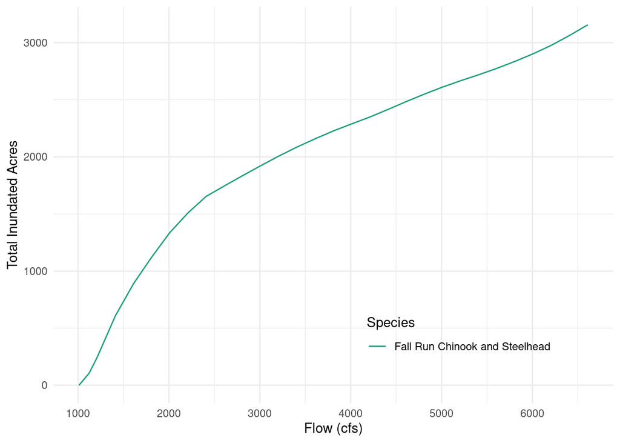